# Converting DF to ndarray using MNIST Digit Recognizer as example

[Dataset Link 1](https://www.kaggle.com/c/digit-recognizer/data)

[Dataset Link 2](http://yann.lecun.com/exdb/mnist/)

The data files train.csv and test.csv contain gray-scale images of hand-drawn digits, from zero through nine.

Each image is 28 pixels in height and 28 pixels in width, for a total of 784 pixels in total. Each pixel has a single pixel-value associated with it, indicating the lightness or darkness of that pixel, with higher numbers meaning darker. This pixel-value is an integer between 0 and 255, inclusive.

The training data set, (train.csv), has 785 columns. The first column, called "label", is the digit that was drawn by the user. The rest of the columns contain the pixel-values of the associated image.

Each pixel column in the training set has a name like pixelx, where x is an integer between 0 and 783, inclusive. To locate this pixel on the image, suppose that we have decomposed x as x = i * 28 + j, where i and j are integers between 0 and 27, inclusive. Then pixelx is located on row i and column j of a 28 x 28 matrix, (indexing by zero).

For example, pixel31 indicates the pixel that is in the fourth column from the left, and the second row from the top, as in the ascii-diagram below.

Visually, if we omit the "pixel" prefix, the pixels make up the image like this:

```
    000 001 002 003 ... 026 027
    028 029 030 031 ... 054 055
    056 057 058 059 ... 082 083
     |   |   |   |  ...  |   |
    728 729 730 731 ... 754 755
    756 757 758 759 ... 782 783
```

The test data set, (test.csv), is the same as the training set, except that it does not contain the "label" column.

Your submission file should be in the following format: For each of the 28000 images in the test set, output a single line containing the ImageId and the digit you predict. For example, if you predict that the first image is of a 3, the second image is of a 7, and the third image is of a 8, then your submission file would look like:

```
    ImageId,Label
    1,3
    2,7
    3,8
    (27997 more lines)
```

The evaluation metric for this contest is the categorization accuracy, or the proportion of test images that are correctly classified. For example, a categorization accuracy of 0.97 indicates that you have correctly classified all but 3% of the images.

```python
import numpy as np
import matplotlib.pyplot as plt
import seaborn as sns
from sklearn.metrics import confusion_matrix
import csv
%matplotlib inline
import pandas as pd

from dnn_utils_v2 import sigmoid, relu, sigmoid_backward, relu_backward

np.random.seed(2)
```

## Reading Data

```python
#using pandas to read dataset
train_data = pd.read_csv('./data/train.csv')
```

```python
train_data.head()
```

|  | label | pixel0 | pixel1 | pixel2 | pixel3 | pixel4 | pixel5 | pixel6 | pixel7 | pixel8 | ... | pixel774 | pixel775 | pixel776 | pixel777 | pixel778 | pixel779 | pixel780 | pixel781 | pixel782 | pixel783 |
| --- | --- | --- | --- | --- | --- | --- | --- | --- | --- | --- | --- | --- | --- | --- | --- | --- | --- | --- | --- | --- | --- |
| 0 | 1 | 0 | 0 | 0 | 0 | 0 | 0 | 0 | 0 | 0 | ... | 0 | 0 | 0 | 0 | 0 | 0 | 0 | 0 | 0 | 0 |
| 1 | 0 | 0 | 0 | 0 | 0 | 0 | 0 | 0 | 0 | 0 | ... | 0 | 0 | 0 | 0 | 0 | 0 | 0 | 0 | 0 | 0 |
| 2 | 1 | 0 | 0 | 0 | 0 | 0 | 0 | 0 | 0 | 0 | ... | 0 | 0 | 0 | 0 | 0 | 0 | 0 | 0 | 0 | 0 |
| 3 | 4 | 0 | 0 | 0 | 0 | 0 | 0 | 0 | 0 | 0 | ... | 0 | 0 | 0 | 0 | 0 | 0 | 0 | 0 | 0 | 0 |
| 4 | 0 | 0 | 0 | 0 | 0 | 0 | 0 | 0 | 0 | 0 | ... | 0 | 0 | 0 | 0 | 0 | 0 | 0 | 0 | 0 | 0 |

5 rows × 785 columns

```python
train_data.shape
```

```
(42000, 785)
```

```python
train_labels = train_data['label']
train_labels.head()
```

```
0    1
1    0
2    1
3    4
4    0
Name: label, dtype: int64
```

```python
#extracting the lebel column from the dataset
train_labels = train_data['label'].values.reshape(42000, 1)
```

```python
train_labels.shape
```

```
(42000, 1)
```

```python
train_labels = train_labels.T
```

```python
type(train_labels)
```

```
numpy.ndarray
```

```python
#since we have extracted the label column, we remove it from the dataset
del train_data['label']
```

```python
train_data.shape
```

```
(42000, 784)
```

At this point I've

- I've read data from dataset using pandas
- removed the label column from the dataset

Now I need to figure out a way to convert the pandas.DataFrame and pandas.Series to numpy array. But before that I'll try to write a routine to display the images in the dataset

```python
image = train_data.iloc[[0]]
```

```python
image.shape
```

```
(1, 784)
```

```python
type(image)
```

```
pandas.core.frame.DataFrame
```

```python
# https://pandas.pydata.org/pandas-docs/stable/generated/pandas.DataFrame.values.html#pandas.DataFrame.values
image = image.values
```

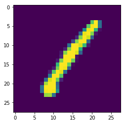

```python
plt.imshow(image.reshape(28, 28))
```

### Displaying the images in the dataset

```python
def show_image(index):
    image = train_data.iloc[[index]]
    image = image.values #convertind the pands.Dataframe to numpy ndarray
    plt.imshow(image.reshape(28, 28))
```

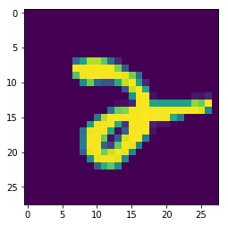

```python
show_image(34)
```

### Converting the pandas dataframe to numpy ndarray

```python
print('For the Dataset: ')
print(train_data.shape)
print(type(train_data))

print('\nFor the labels: ')
print(train_labels.shape)
print(type(train_labels))
```

```
For the Dataset:
(42000, 784)
<class 'pandas.core.frame.DataFrame'>

For the labels:
(1, 42000)
<class 'numpy.ndarray'>
```

So now we need to convert the train_data to numpy ndarray

```python
train_data = train_data.values
print(train_data.shape)
print(type(train_data))
```

```
(42000, 784)
<class 'numpy.ndarray'>
```

```python
train_data = train_data.T
print(train_data.shape)
```

```
(784, 42000)
```

I will load the test set later

# References

- https://stackoverflow.com/questions/42240376/dataframe-object-has-no-attribute-reshape
- https://stackoverflow.com/questions/38308378/tensorflow-show-image-from-mnist-dataset
- https://stackoverflow.com/questions/46317216/numpy-ndarray-object-is-not-callable-using-pandas